# Fire Sensitive Speleothem

Following article “Past fires and post-fire impacts reconstructed from a southwest Australian stalagmite” ~ L.K. McDonough et al. 2022.

Start by loading packages and importing data (excel downloaded from https://www.sciencedirect.com/science/article/abs/pii/S0016703722001454) Method 1) Using Excel, save data as .csv. Remove everything except column headers and data (*Note). Read as with previous data, using read_csv Method 2) Showcased here. Tidyverse readexcel package is new to us.

```r
setwd("~/Dropbox/R_on_git/R_Speleothem")
#data input and manipulation
library(tidyverse)
library(tidymodels)
#install.packages("readxl")
library(readxl)
#EDA
# install.packages("corrplot")
library(corrplot)
#Time series analysis
# install.packages('zoo')
library(zoo)
#PCA
# install.packages("FactoMineR")
# install.packages("factoextra")
library(FactoMineR)
library(factoextra)
```

Import data and take a look. Always look at your variables to avoid headaches later.

```r
#import
hi_res <- read_excel(path = "1-s2.0-S0016703722001454-mmc1.xlsx",sheet =1 )
#take a look
hi_res
```

| DFT (mm) | Year (CE) | Organic matter (relative greyscale concentration) | δ13C (‰) | δ18O (‰) | Mg (ppm) | P (ppm) | Sr (ppm) | Ba (ppm) | U (ppm) | Al (ppm) | Zn (ppm) | Cu (ppm) | Pb (ppm) | S (relative greyscale concentration) | Br (ppm) smoothed using 13 point Savitsky Golay filter | ...17 | *NOTE: This data is for the high resolution PCA. Data has been interpolated to the LA-ICP-MS data (0.0063mm resolution). The maximum and minimum DFT values for data utilised in the PCA are constrained… |
| --- | --- | --- | --- | --- | --- | --- | --- | --- | --- | --- | --- | --- | --- | --- | --- | --- | --- |
| 18.84601 | 1759.635 | 121.56218 | -5.47110 | -2.78936 | 2507.014 | 3.047448 | 361.6691 | 16.45177 | 0.08096855 | 8.034644 | 4.661594000 | 0.531559748 | -0.000868212 | 185.9911 | 17.72896 | NA | NA |
| 18.83969 | 1759.681 | 115.76670 | -5.49107 | -2.79918 | 2379.106 | 3.428379 | 360.3986 | 16.23205 | 0.08569761 | 8.129074 | 5.047336000 | 0.584342327 | 0.013814376 | 178.8730 | 16.81415 | NA | NA |
| 18.83338 | 1759.727 | 115.65984 | -5.51100 | -2.80899 | 2342.768 | 3.391215 | 365.8223 | 15.73767 | 0.11500493 | 8.517586 | 2.092160000 | 0.660878400 | 0.013833294 | 169.0937 | 16.55991 | NA | NA |
| 18.82707 | 1759.773 | 116.00000 | -5.53094 | -2.81880 | 2330.494 | 3.078418 | 368.3370 | 15.54542 | 0.11138947 | 8.876420 | 1.516816000 | 0.622072129 | 0.003891879 | 162.0581 | 15.91117 | NA | NA |
| 18.82076 | 1759.819 | 116.00000 | -5.55087 | -2.82860 | 2339.760 | 2.514764 | 368.2318 | 15.61408 | 0.07830962 | 9.210972 | 3.079398000 | 0.480989206 | -0.014963528 | 149.7436 | 16.63551 | NA | NA |
| 18.81444 | 1759.865 | 115.44599 | -5.57083 | -2.83843 | 2289.711 | 2.833755 | 365.2965 | 15.50422 | 0.08522851 | 9.389040 | 3.170930000 | 0.373654928 | -0.010298192 | 136.0828 | 16.04648 | NA | NA |
| 18.80813 | 1759.911 | 113.68115 | -5.59077 | -2.84823 | 2228.835 | 3.341663 | 362.4051 | 15.31196 | 0.09842657 | 9.526638 | 2.935562000 | 0.284806817 | -0.002193937 | 135.3256 | 16.53070 | NA | NA |
| 18.80182 | 1759.958 | 110.44250 | -5.61070 | -2.85804 | 2174.816 | 3.920802 | 363.4215 | 14.80385 | 0.10059213 | 9.618370 | 2.517130000 | 0.269327647 | -0.002167871 | 135.5383 | 16.40879 | NA | NA |
| 18.79551 | 1760.004 | 102.52425 | -5.63063 | -2.86785 | 2098.009 | 4.512329 | 362.7906 | 14.30947 | 0.09533994 | 9.308100 | 2.203306000 | 0.282775887 | 0.001918459 | 136.7056 | 16.05681 | NA | NA |
| 18.78919 | 1760.050 | 91.52259 | -5.65060 | -2.87767 | 1992.491 | 5.131729 | 360.1007 | 13.81510 | 0.08074174 | 8.493304 | 2.020242000 | 0.332670300 | 0.011120362 | 138.9787 | 16.07330 | NA | NA |

[output cut: 990 more lines]

```r
NA
```

So far looks good. Now for some QC.

```r
#look at column names
colnames(hi_res)
```

```
 [1] "DFT (mm)"
 [2] "Year (CE)"
 [3] "Organic matter (relative greyscale concentration)"
 [4] "\u03b413C (\u2030)"
 [5] "\u03b418O (\u2030)"
 [6] "Mg (ppm)"
 [7] "P (ppm)"
 [8] "Sr (ppm)"
 [9] "Ba (ppm)"
[10] "U (ppm)"
[11] "Al (ppm)"
[12] "Zn (ppm)"
[13] "Cu (ppm)"
[14] "Pb (ppm)"
[15] "S (relative greyscale concentration)"
[16] "Br (ppm) smoothed using 13 point Savitsky Golay filter"
[17] "...17"
[18] "*NOTE: This data is for the high resolution PCA. Data has been interpolated to the LA-ICP-MS data (0.0063mm resolution). The maximum and minimum DFT values for data utilised in the PCA are constrained by the maximum and minimum DFT values of the stable isotope data (0.05 - 18.85 mm DFT)*"
```

```r
#drop 17 and 18, these are empty range in the excel table cause by the *NOTE entry
hi_res <- hi_res %>% select(-(c(17,18)))
#look at the column names
colnames(hi_res)
```

```
 [1] "DFT (mm)"                                               "Year (CE)"
 [3] "Organic matter (relative greyscale concentration)"      "\u03b413C (\u2030)"
 [5] "\u03b418O (\u2030)"                                     "Mg (ppm)"
 [7] "P (ppm)"                                                "Sr (ppm)"
 [9] "Ba (ppm)"                                               "U (ppm)"
[11] "Al (ppm)"                                               "Zn (ppm)"
[13] "Cu (ppm)"                                               "Pb (ppm)"
[15] "S (relative greyscale concentration)"                   "Br (ppm) smoothed using 13 point Savitsky Golay filter"
```

```r
#i don't like the way the deltas came in, change them
hi_res<-rename(hi_res, d18O="\u03b418O (\u2030)")
hi_res<-rename(hi_res, d13C="\u03b413C (\u2030)")
#these long names will wreak havoc later, change them
hi_res<-rename(hi_res, "Br (ppm)"="Br (ppm) smoothed using 13 point Savitsky Golay filter")
hi_res<-rename(hi_res, "OM (rgc)"="Organic matter (relative greyscale concentration)")
hi_res<-rename(hi_res, "S (rgc)"="S (relative greyscale concentration)")
colnames(hi_res)
```

```
 [1] "DFT (mm)"  "Year (CE)" "OM (rgc)"  "d13C"      "d18O"      "Mg (ppm)"  "P (ppm)"   "Sr (ppm)"  "Ba (ppm)"  "U (ppm)"
[11] "Al (ppm)"  "Zn (ppm)"  "Cu (ppm)"  "Pb (ppm)"  "S (rgc)"   "Br (ppm)"
```

```r
#better
```

Data structure (i.e., the tibble) is looking clean. Let’s do some EDA (exploratory data analysis) I’m going to rearrange the data so it is more convenient for plotting. I’ll use tidyr::pivot_longer() to convert to a ‘long’ format, wherein each row is a single observation (i.e., data column), rather than a group of observations (several data columns) for a single timepoint.

```r
#you can print summar statistics for every column using
summary(hi_res)
```

```
    DFT (mm)          Year (CE)       OM (rgc)            d13C             d18O           Mg (ppm)         P (ppm)
 Min.   : 0.05397   Min.   :1760   Min.   :  6.502   Min.   :-7.488   Min.   :-4.588   Min.   : 717.7   Min.   :  0.6999
 1st Qu.: 4.75198   1st Qu.:1813   1st Qu.: 53.097   1st Qu.:-6.766   1st Qu.:-3.691   1st Qu.:1245.7   1st Qu.:  2.2980
 Median : 9.44999   Median :1896   Median : 72.716   Median :-6.229   Median :-3.461   Median :1761.1   Median :  3.1171
 Mean   : 9.44999   Mean   :1882   Mean   : 77.970   Mean   :-6.005   Mean   :-3.378   Mean   :1845.6   Mean   :  4.3930
 3rd Qu.:14.14800   3rd Qu.:1950   3rd Qu.: 99.445   3rd Qu.:-5.439   3rd Qu.:-3.100   3rd Qu.:2398.3   3rd Qu.:  4.8081
 Max.   :18.84601   Max.   :2003   Max.   :187.890   Max.   :-2.329   Max.   :-1.941   Max.   :3870.8   Max.   :161.2020
    Sr (ppm)        Ba (ppm)         U (ppm)           Al (ppm)         Zn (ppm)          Cu (ppm)
 Min.   :238.5   Min.   : 6.276   Min.   :0.01721   Min.   : 1.997   Min.   :-0.4634   Min.   :-0.08772
 1st Qu.:319.7   1st Qu.: 8.830   1st Qu.:0.06743   1st Qu.: 5.561   1st Qu.: 0.7257   1st Qu.: 0.03471
 Median :346.1   Median :12.703   Median :0.08226   Median : 6.251   Median : 1.2161   Median : 0.06667
 Mean   :345.4   Mean   :12.711   Mean   :0.08511   Mean   : 6.525   Mean   : 1.5357   Mean   : 0.11565
 3rd Qu.:368.6   3rd Qu.:15.872   3rd Qu.:0.10025   3rd Qu.: 7.095   3rd Qu.: 1.8764   3rd Qu.: 0.10224
 Max.   :449.6   Max.   :22.741   Max.   :0.17588   Max.   :40.637   Max.   :18.5483   Max.   :16.32497
    Pb (ppm)           S (rgc)          Br (ppm)
 Min.   :-0.01838   Min.   : 62.00   Min.   :10.92
 1st Qu.:-0.00138   1st Qu.: 98.89   1st Qu.:14.28
 Median : 0.01394   Median :119.43   Median :15.60
 Mean   : 0.29726   Mean   :127.18   Mean   :15.54
 3rd Qu.: 0.04446   3rd Qu.:147.30   3rd Qu.:16.79
 Max.   :78.13512   Max.   :249.52   Max.   :21.03
```

```r
#drop columns not used in rolling average plot, and lengthen data
hi_res_long <-  hi_res %>% select(!c("Al (ppm)", "Pb (ppm)", "Cu (ppm)","Zn (ppm)"))%>%
  pivot_longer(!c("DFT (mm)","Year (CE)"),names_to = "Type",values_to = "Observation") %>% group_by(Type)

#take a look
hi_res_long
```

| DFT (mm) | Year (CE) | Type | Observation |
| --- | --- | --- | --- |
| 18.84601 | 1759.635 | OM (rgc) | 121.56218000 |
| 18.84601 | 1759.635 | d13C | -5.47110000 |
| 18.84601 | 1759.635 | d18O | -2.78936000 |
| 18.84601 | 1759.635 | Mg (ppm) | 2507.01399000 |
| 18.84601 | 1759.635 | P (ppm) | 3.04744800 |
| 18.84601 | 1759.635 | Sr (ppm) | 361.66907400 |
| 18.84601 | 1759.635 | Ba (ppm) | 16.45177460 |
| 18.84601 | 1759.635 | U (ppm) | 0.08096855 |
| 18.84601 | 1759.635 | S (rgc) | 185.99110000 |
| 18.84601 | 1759.635 | Br (ppm) | 17.72896000 |

[output cut: 990 more lines]

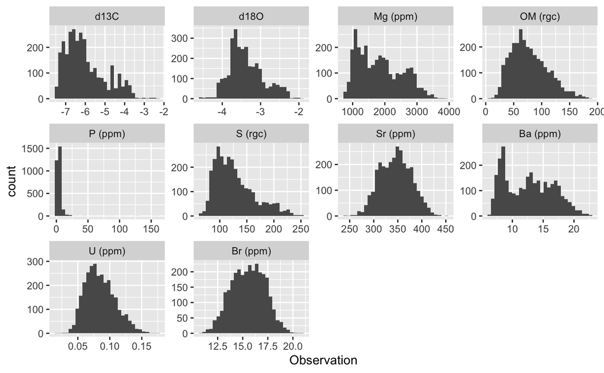

```r
#make the new Type variable a factor (categorical) variable, and tell R what the order should be
hi_res_long$Type <- factor(hi_res_long$Type,
  levels = c("d13C","d18O",
 "Mg (ppm)","OM (rgc)",
  "P (ppm)","S (rgc)",
 "Sr (ppm)","Ba (ppm)",
  "U (ppm)","Br (ppm)"))

#histograms of all variables
ggplot(data = hi_res_long)+geom_histogram(aes(x=Observation))+facet_wrap(Type~.,scales = "free")
```

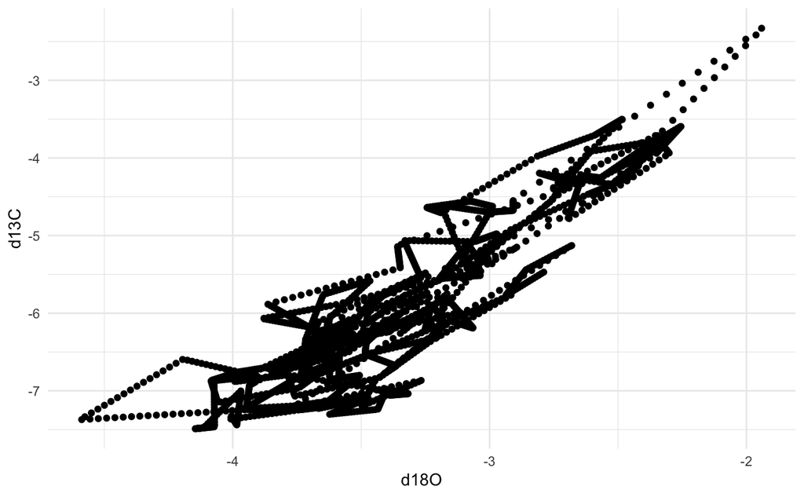

```r
#d18O and d13C scatterplot. nonequillibrium processes at play?
ggplot(data = hi_res)+geom_point(aes(x=d18O, y=d13C))+theme_minimal()
```

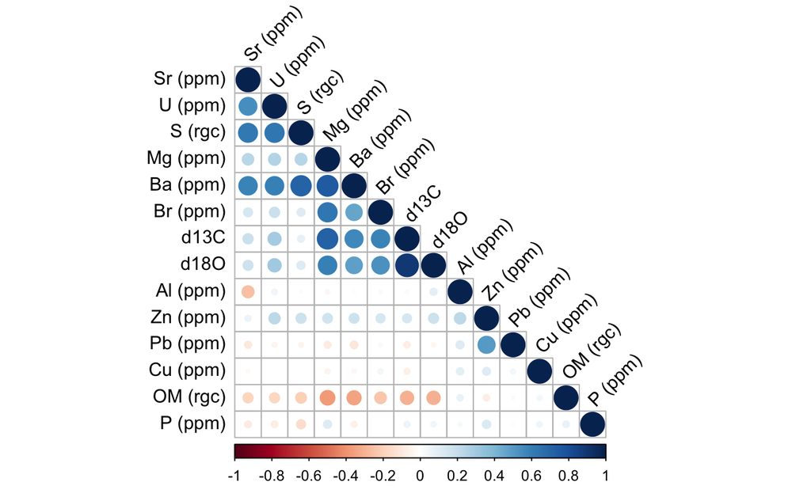

```r
#pairwise correlations?  stats::cor and corrplot::corrplot
hi_res_corr <- hi_res %>% select(!c("DFT (mm)","Year (CE)")) %>% cor()
corrplot(hi_res_corr, type = "lower", order = "hclust",
         tl.col = "black", tl.srt = 45)
```

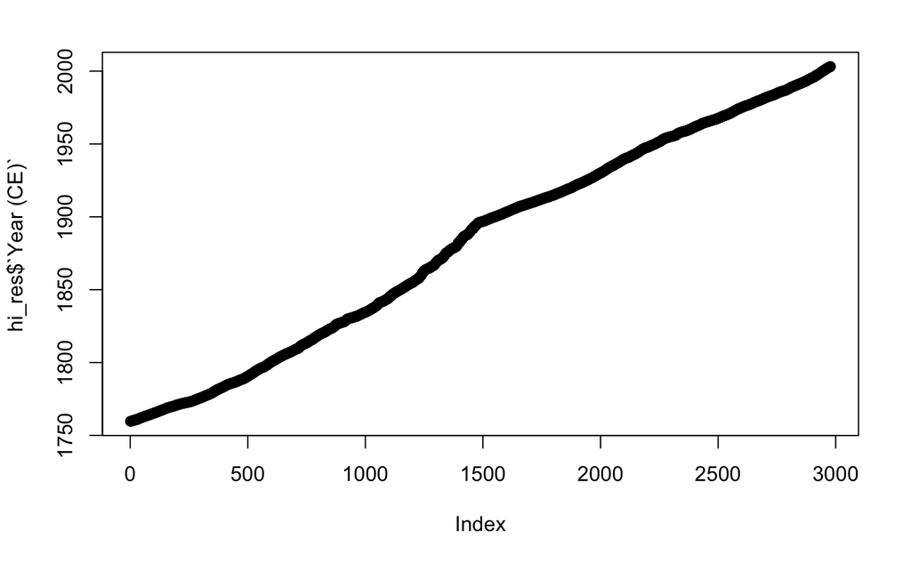

```r
#since we're doing time series analysis, lets also look at the time variable
#this is the base R plotting function, fine for single variables
plot(hi_res$`Year (CE)`)
```

Now following article “Past fires and post-fire impacts reconstructed from a southwest Australian stalagmite” ~ L.K. McDonough et al. 2022. overlay raw data with 5-year moving average (100 timesteps)

I’ll check the time intervals for irregularity using zoo::is.regular…they turn out to be irregular. I’ll use the rollmean function from the zoo package, which is intended for use with irregular time series to calculate the rolling mean separately for each data column. This may not affect the outcome very much, but there’s no reason not to use the best tool for the job. It’s a good idea to look into the packages you use. (https://cran.r-project.org/web/packages/zoo/index.html, doi: 10.18637/jss.v014.i06)

```r
#alternatively, we could use stats from base R do define a filter to calculate moving average like this
# ma <- function(x, n = 100){stats::filter(x, base::rep(1 / n, n), sides = 2)}
#where n is the window size, rep 1/n produces an even weighting, and sides = 2 produces a centered rolling mean
#or we could use lapply
#the problem with this is that it is not robust to uneven time intervals

#directly check to see if the time series is strictly regular as proivded
is.regular(zoo(x=hi_res$d13C,order.by = hi_res$`Year (CE)`))
```

```
[1] FALSE
```

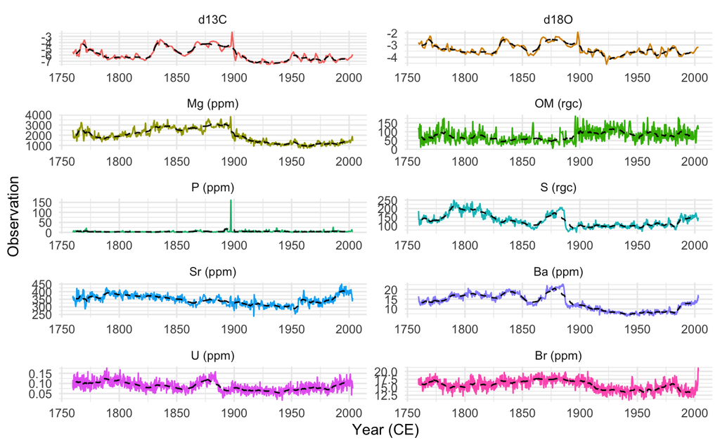

```r
#three nested functions to be applied groupwise below
#read from inside out: store as zoo datatype, calculate rolling mean, then store as numeric vector
my_rollmean <- function(x, na.rm=FALSE)(as.numeric(rollmean(zoo(x,order.by = hi_res$`Year (CE)`), k=100, fill = NA)))

#calculate group means for each non-index column, then store like '_long' above
hi_res_means <- hi_res %>% mutate_at(vars(-'DFT (mm)', -'Year (CE)'), my_rollmean)%>%  #apply custom function
  select(!c("Al (ppm)", "Pb (ppm)", "Cu (ppm)","Zn (ppm)"))%>% #drop columns that the paper skips
  pivot_longer(!c("DFT (mm)","Year (CE)"),names_to = "Type",values_to = "Observation") %>% #make observations long by Type
  group_by(Type) #tell R that the Type column is a partition of the observations

#i can define an ordering for the observation types so they plot in the same order as the paper
hi_res_means$Type <- factor(hi_res_means$Type,
  levels = c("d13C","d18O",
 "Mg (ppm)","OM (rgc)",
  "P (ppm)","S (rgc)",
 "Sr (ppm)","Ba (ppm)",
  "U (ppm)","Br (ppm)"))

#build plot
p<-ggplot()+
  #new technique here, separate but same-shaped datasets being passed to data in separate geoms
    geom_line(data = hi_res_long,aes(x=`Year (CE)`, y=Observation, color = Type))+#lines for dat
    geom_line(data = hi_res_means,aes(x=`Year (CE)`, y=Observation),color='black', linetype='dashed')+ #lines for rollmean
  #update formatting and break out by observation type
    theme_minimal()+facet_wrap(Type~.,scales = "free",ncol = 2)+
    theme(legend.position = 'none')

#view plot
p
#why the warning, how would we trace back the problem?
#try changing the fill value in  my_rollmean() to -999 and replotting
#is this really a problem?

#also not so good to look at, lets save and view separately
ggsave("raw_plus_rollmean_FireSpeleothem.png", plot = p, device = "png",
       scale = 1, height = 8.5, width = 11, units = c("in"),
       dpi = 300, limitsize = TRUE)
```

```r
NA
NA
NA
```

Smooth transition to PCA. First we need to create a matrix of outcomes without independent variables (x), then we can run the PCA.

(For some background, I recommend looking at https://towardsdatascience.com/a-one-stop-shop-for-principal-component-analysis-5582fb7e0a9c).

The purpose of PCA is to take high-dimensional data (in this case 14 dimensions), find out what is contributing the most to the overall variation in the dataset, and plot the variation in fewer dimensions. In this case, we’re going to scale the obserations using the variance (scale.unit=TRUE). This is good because we’re looking at a bunch of observation types with different units (i.e., ppm & relative concentration, that are not directly comparable), with very different variances (e.g., Br and U). Try the code without scaling to see how it affects the outcome.

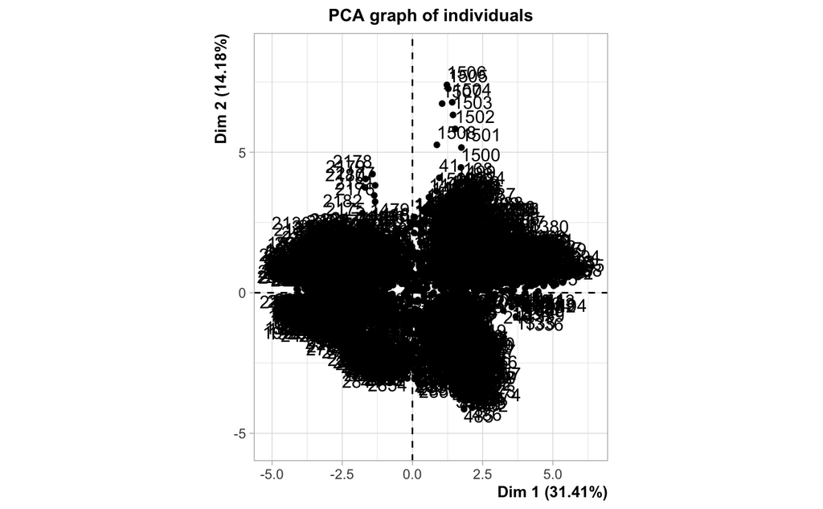

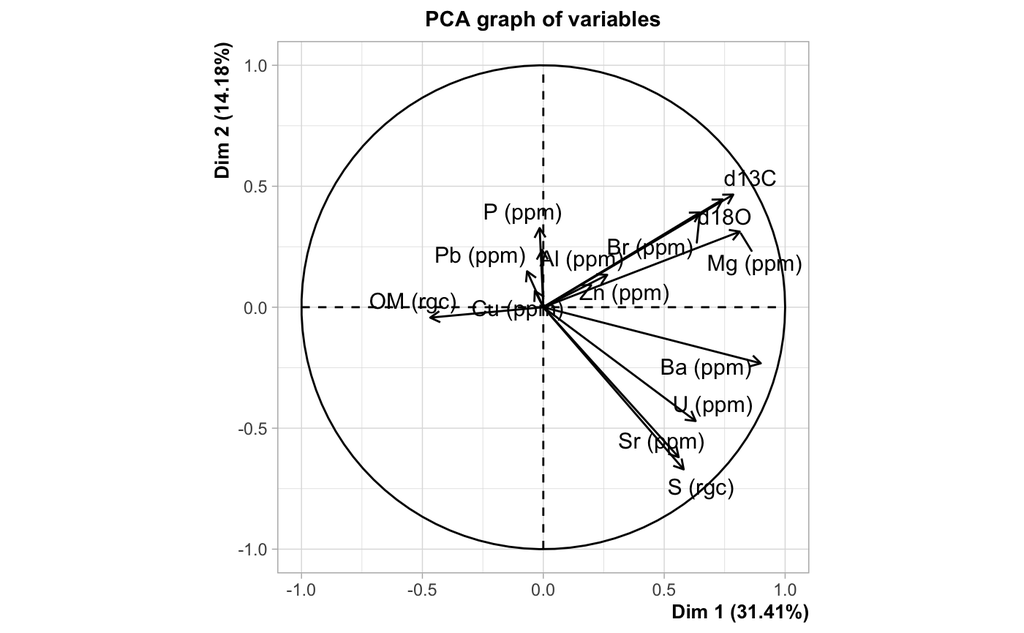

```r
#drop 'independent variables'
x<-subset(hi_res, select=-c(`DFT (mm)`,`Year (CE)`))
#perform PCA with scaling
unit<-PCA(X = x, scale.unit = TRUE)
```

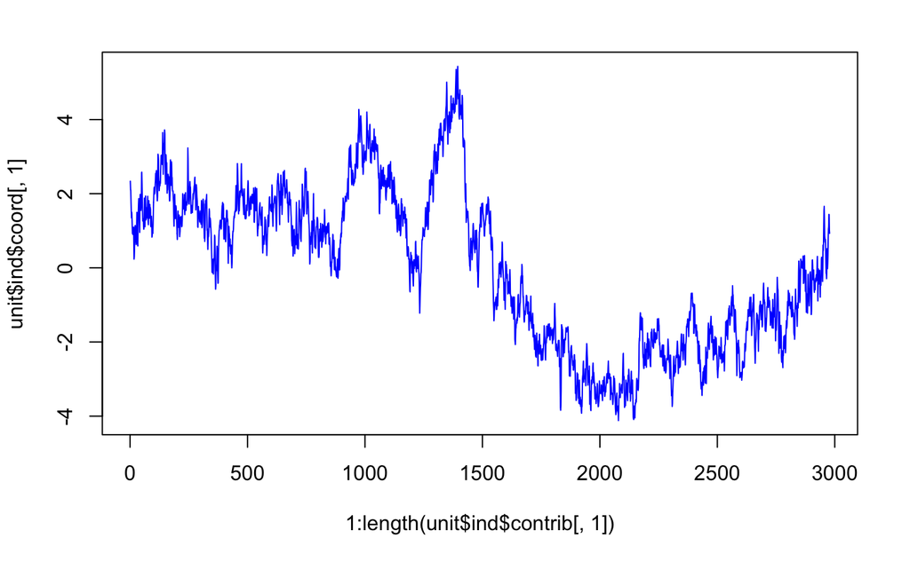

```r
#...without scaling
# var<-PCA(X = x, scale.unit = FALSE)
#plot individual datapoints in 'timeXPC space'
plot(1:length(unit$ind$contrib[,1]),unit$ind$coord[,1],type = 'l', col='blue')
```

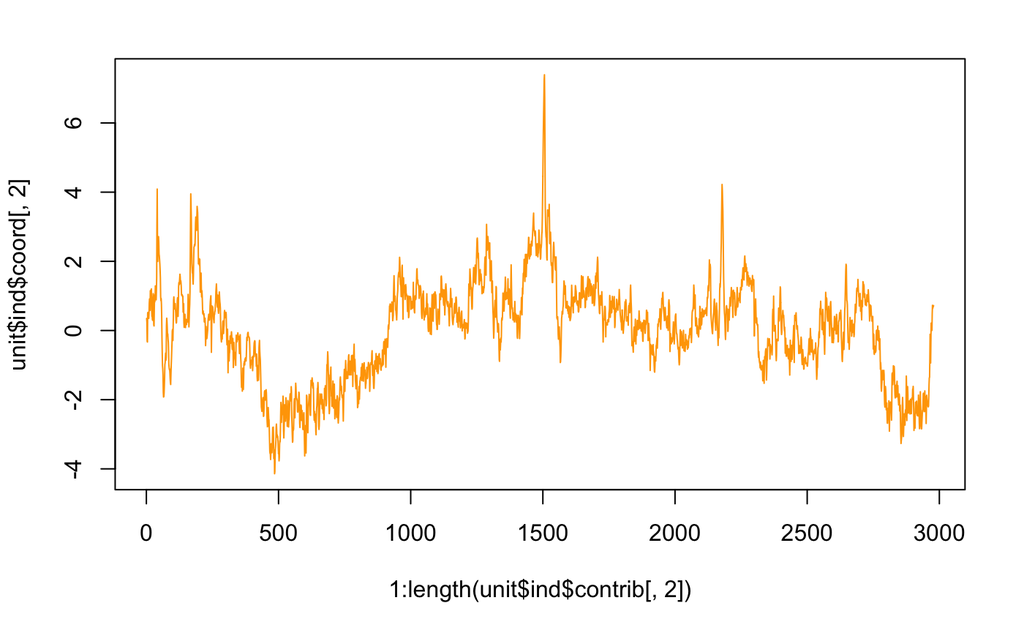

```r
plot(1:length(unit$ind$contrib[,2]),unit$ind$coord[,2],type = 'l', col='orange')
```

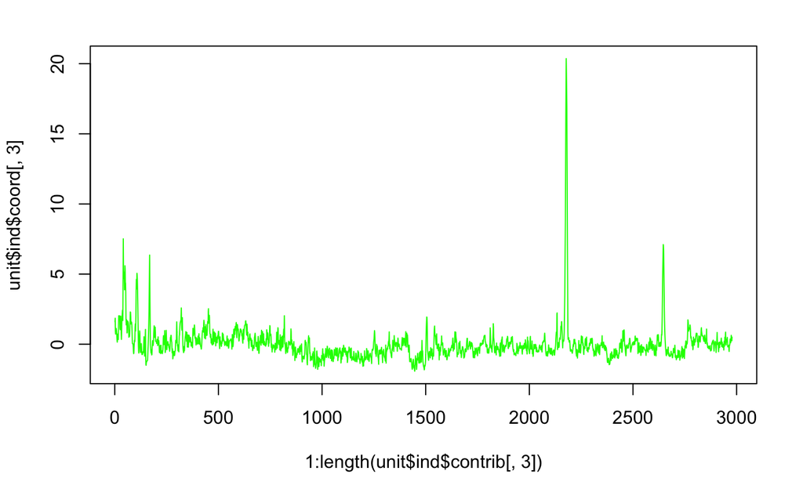

```r
plot(1:length(unit$ind$contrib[,3]),unit$ind$coord[,3],type = 'l', col='green')
```

```r
unit$eig
```

```
        eigenvalue percentage of variance cumulative percentage of variance
comp 1  4.39731596             31.4093997                          31.40940
comp 2  1.98458329             14.1755949                          45.58499
comp 3  1.65982907             11.8559220                          57.44092
comp 4  1.06377307              7.5983791                          65.03930
comp 5  0.99962797              7.1401998                          72.17950
comp 6  0.93386149              6.6704392                          78.84993
comp 7  0.76361265              5.4543761                          84.30431
comp 8  0.62818945              4.4870675                          88.79138
comp 9  0.42121733              3.0086952                          91.80007
comp 10 0.41039810              2.9314150                          94.73149
comp 11 0.35334555              2.5238968                          97.25539
comp 12 0.25465705              1.8189789                          99.07436
comp 13 0.07276255              0.5197325                          99.59410
comp 14 0.05682647              0.4059033                         100.00000
```

```r
unit$svd$V
```

```
              [,1]        [,2]         [,3]         [,4]         [,5]
 [1,] -0.222967499 -0.03054869  0.062466433  0.406172678  0.031216511
 [2,]  0.374653934  0.33053537 -0.118581633 -0.012616016 -0.042211729
 [3,]  0.353657382  0.31623067 -0.050102082  0.017072867 -0.101220234
 [4,]  0.387402024  0.22185525 -0.106034426 -0.002773518  0.097904685
 [5,] -0.007243393  0.23229468  0.087753689  0.385639854  0.710608360
 [6,]  0.266955657 -0.43999789 -0.021508331  0.014259712  0.234493764
 [7,]  0.428937177 -0.16454302 -0.006289153  0.063395994 -0.003026254
 [8,]  0.300392424 -0.33392659  0.161393394  0.143100731 -0.073740636
 [9,] -0.002366950  0.16819625  0.374421026  0.326997087 -0.602162651
[10,]  0.126064994  0.09494174  0.624287359 -0.136681608  0.150889400
[11,] -0.016692184  0.04790775  0.222265601  0.569303606  0.019570564
[12,] -0.031940841  0.10549285  0.572472824 -0.450533331  0.146415186
[13,]  0.276827791 -0.47577779  0.151089945  0.088417411 -0.047842203
[14,]  0.308860962  0.27813470 -0.064428325  0.025172121 -0.050375295
```

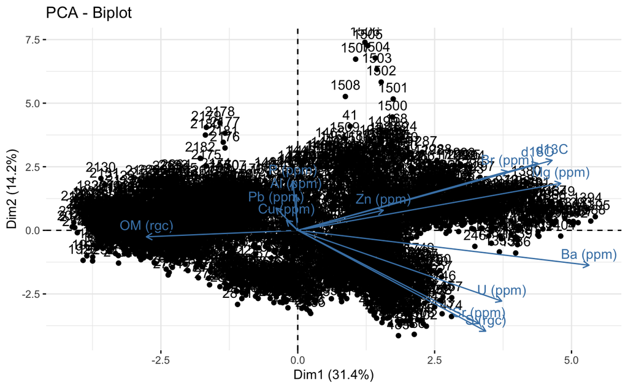

```r
#biplot and cor plot are essentially the same.
#rotated data in biplot with arrows showing correlation of variables and axes
#default biplot
fviz_pca_biplot(unit)
```

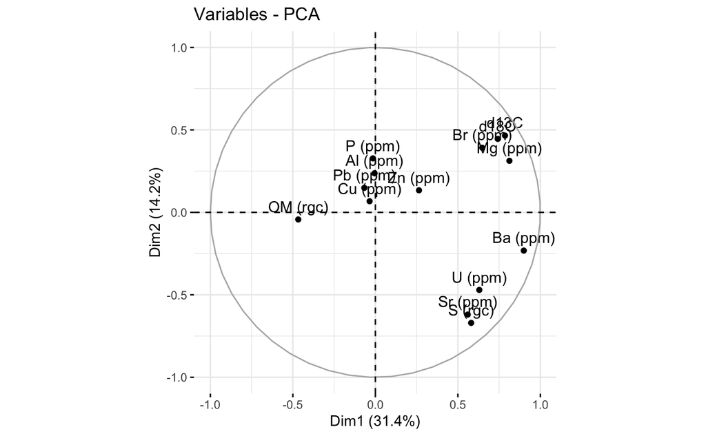

```r
#cor plot with just variables and unit cor circle
fviz_pca_var(unit,geom = c("point","text"))
```

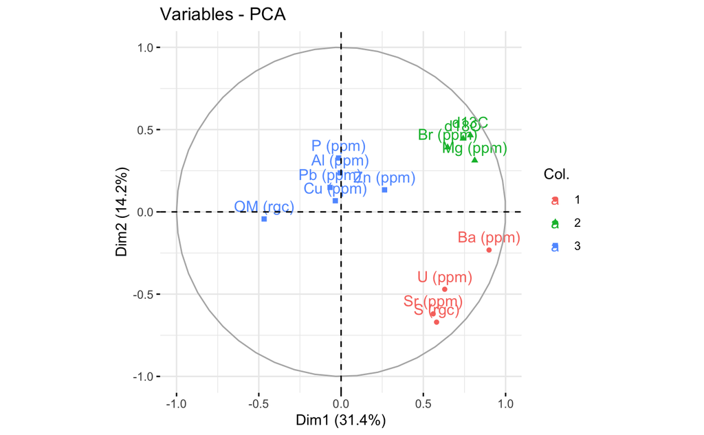

```r
#cluster variables in pc space
#high featured package
# unit.hcpc <- HCPC(unit, graph = FALSE)
#following paper
set.seed(162)
unit.kmeans<-kmeans(unit$var$coord, centers = 3, nstart = 25)
grps <- as.factor(unit.kmeans$cluster)
fviz_pca_var(unit,geom = c("point","text"),col.var = grps)
```

```r
#fviz_pca_biplot(unit.hcpc$desc.axes,geom = "point",col.var = )
#... but with a whimper...
```